# 3. Data Visualization

## Visualization

We finally have our data in a memory-optimized format, and we have weather data for each flight! Let's make some visualizations!

Let's start by looking at flights that were cancelled due to weather. We'll drop all the flights that were cancelled for reasons other than weather.

```python
# Import our data from the previous notebook
import pandas as pd
import matplotlib.pyplot as plt
import seaborn as sns
import numpy as np
import warnings
warnings.filterwarnings('ignore')
%matplotlib inline
pd.set_option('display.max_columns', 35)

flights = pd.read_csv('flights_with_wx.csv',
                      dtype= {'DAY_OF_WEEK': 'uint8',
                             'AIRLINE': 'category',
                             'ORIGIN_AIRPORT': 'category',
                             'DESTINATION_AIRPORT': 'category',
                             'DEPARTURE_DELAY': 'float32',
                             'ARRIVAL_DELAY': 'float32',
                             'DIVERTED': 'uint8',
                             'CANCELLED': 'uint8',
                             'CANCELLATION_REASON': 'category',
                             'ORIGIN_CEILING': 'uint16',
                             'ORIGIN_VISIBILITY': 'float16',
                             'ORIGIN_WIND_SPEED': 'float16',
                             'ORIGIN_PRECIPITATION': 'float32',
                             'DESTINATION_CEILING': 'uint16',
                             'DESTINATION_VISIBILITY': 'float16',
                             'DESTINATION_WIND_SPEED': 'float16',
                             'DESTINATION_PRECIPITATION': 'float32'},
                      parse_dates=['SCHEDULED_DEPARTURE', 'SCHEDULED_ARRIVAL'])
flights.drop('Unnamed: 0', axis=1, inplace=True)
```

```python
flights_with_wxcx = flights[(flights['CANCELLATION_REASON'] != 'A') & (flights['CANCELLATION_REASON'] != 'C') & (flights['CANCELLATION_REASON'] != 'D')]
flights_with_wxcx.drop('CANCELLATION_REASON', axis=1, inplace=True)
```

A little additional massaging: we'll fill in any missing data with the average values for that column, and also set the maximum cloud ceiling to 25000 ft. The vast majority of airports do not report clouds above 25000 ft, and clouds that high aren't relevant for takeoff and landing operations anyway.

```python
flights_with_wxcx['ORIGIN_VISIBILITY'].fillna(10, inplace=True)
flights_with_wxcx['ORIGIN_WIND_SPEED'].fillna(7, inplace=True)
flights_with_wxcx['ORIGIN_PRECIPITATION'].fillna(0, inplace=True)
flights_with_wxcx['DESTINATION_VISIBILITY'].fillna(10, inplace=True)
flights_with_wxcx['DESTINATION_WIND_SPEED'].fillna(7, inplace=True)
flights_with_wxcx['DESTINATION_PRECIPITATION'].fillna(0, inplace=True)
flights_with_wxcx.loc[flights_with_wxcx['ORIGIN_CEILING'] > 25000, 'ORIGIN_CEILING'] = 25000
flights_with_wxcx.loc[flights_with_wxcx['DESTINATION_CEILING'] > 25000, 'DESTINATION_CEILING'] = 25000
```

A quick way to see if our hypothesis of worse weather leads to more flight delays is to just plot out our variables. However, with ~5 million datapoints, a scatterplot would be overwhelming. For something like that, Tableau might be more capabale, rather than matplotlib. Let's try plotting the percent of flights cancelled versus our weather variables.

[output not shown]

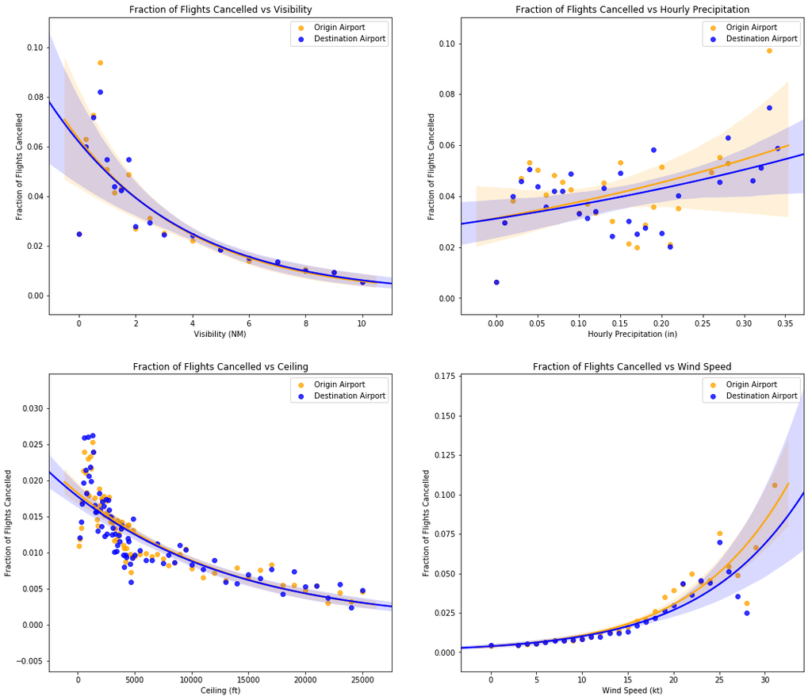

```python
fig, ax = plt.subplots(ncols=2, nrows=2, figsize=(18,16))

# Plot the percent of flights cancelled vs Origin Airport Visibility and include a regression line
df = flights_with_wxcx[(flights_with_wxcx['ORIGIN_VISIBILITY'] % .25 == 0) & (flights_with_wxcx['ORIGIN_VISIBILITY'] != 2.25) & (flights_with_wxcx['ORIGIN_VISIBILITY'] != 2.75)].groupby(['CANCELLED','ORIGIN_VISIBILITY']).size()
df_pct=df[1]/df[0]
df_pct = df_pct.reset_index().rename({0:'Fraction Cancelled'}, axis=1)
sns.regplot('ORIGIN_VISIBILITY', 'Fraction Cancelled', df_pct, logistic=True, ax=ax[0,0], color='orange', label='Origin Airport')

# Plot the percent of flights cancelled vs Destination Airport Visibility and include a regression line
df = flights_with_wxcx[(flights_with_wxcx['DESTINATION_VISIBILITY'] % .25 == 0) & (flights_with_wxcx['DESTINATION_VISIBILITY'] != 2.25) & (flights_with_wxcx['DESTINATION_VISIBILITY'] != 2.75)].groupby(['CANCELLED','DESTINATION_VISIBILITY']).size()
df_pct=df[1]/df[0]
df_pct = df_pct.reset_index().rename({0:'Fraction Cancelled'}, axis=1)
sns.regplot('DESTINATION_VISIBILITY', 'Fraction Cancelled', df_pct, logistic=True, ax=ax[0,0], color='b', label='Destination Airport')

ax[0,0].legend()
ax[0,0].set(xlabel='Visibility (NM)', ylabel='Fraction of Flights Cancelled', title='Fraction of Flights Cancelled vs Visibility')

# Plot the percent of flights cancelled vs Origin Airport Ceiling and include a regression line
df = flights_with_wxcx.groupby(['CANCELLED','ORIGIN_CEILING']).size()
df_pct=df[df>20][1]/df[df>20][0] # Ignore outlying groups with fewer than 20 entries
df_pct = df_pct.reset_index().rename({0:'Fraction Cancelled'}, axis=1)
sns.regplot('ORIGIN_CEILING', 'Fraction Cancelled', df_pct, logistic=True, ax=ax[1,0], color='orange', label='Origin Airport')

# Plot the percent of flights cancelled vs Destination Airport Ceiling and include a regression line
df = flights_with_wxcx.groupby(['CANCELLED','DESTINATION_CEILING']).size()
df_pct=df[df>20][1]/df[df>20][0] # Ignore outlying groups with fewer than 20 entries
df_pct = df_pct.reset_index().rename({0:'Fraction Cancelled'}, axis=1)
sns.regplot('DESTINATION_CEILING', 'Fraction Cancelled', df_pct, logistic=True, ax=ax[1,0], color='b', label='Destination Airport')

ax[1,0].legend()
ax[1,0].set(xlabel='Ceiling (ft)', ylabel='Fraction of Flights Cancelled', title='Fraction of Flights Cancelled vs Ceiling')

# Plot the percent of flights cancelled vs Origin Airport Precipitation and include a regression line
df = flights_with_wxcx.groupby(['CANCELLED','ORIGIN_PRECIPITATION']).size()
df_pct=df[df>20][1]/df[df>20][0] # Ignore outlying groups with fewer than 20 entries
df_pct = df_pct.reset_index().rename({0:'Fraction Cancelled'}, axis=1)
sns.regplot('ORIGIN_PRECIPITATION', 'Fraction Cancelled', df_pct, logistic=True, ax=ax[0,1], color='orange', label='Origin Airport')

# Plot the percent of flights cancelled vs Destination Airport Precipitation and include a regression line
df = flights_with_wxcx.groupby(['CANCELLED','DESTINATION_PRECIPITATION']).size()
df_pct=df[df>20][1]/df[df>20][0] # Ignore outlying groups with fewer than 20 entries
df_pct = df_pct.reset_index().rename({0:'Fraction Cancelled'}, axis=1)
sns.regplot('DESTINATION_PRECIPITATION', 'Fraction Cancelled', df_pct, logistic=True, ax=ax[0,1], color='blue', label='Destination Airport')

ax[0,1].legend()
ax[0,1].set(xlabel='Hourly Precipitation (in)', ylabel='Fraction of Flights Cancelled', title='Fraction of Flights Cancelled vs Hourly Precipitation')

# Plot the percent of flights cancelled vs Origin Airport Wind Speed and include a regression line
df = flights_with_wxcx.groupby(['CANCELLED','ORIGIN_WIND_SPEED']).size()
df_pct=df[df>20][1]/df[df>20][0] # Ignore outlying groups with fewer than 20 entries
df_pct = df_pct.reset_index().rename({0:'Fraction Cancelled'}, axis=1)
sns.regplot('ORIGIN_WIND_SPEED', 'Fraction Cancelled', df_pct, logistic=True, ax=ax[1,1], color='orange', label='Origin Airport')

# Plot the percent of flights cancelled vs Destination Airport Wind Speed and include a regression line
df = flights_with_wxcx.groupby(['CANCELLED','DESTINATION_WIND_SPEED']).size()
df_pct=df[df>20][1]/df[df>20][0] # Ignore outlying groups with fewer than 20 entries
df_pct = df_pct.reset_index().rename({0:'Fraction Cancelled'}, axis=1)
sns.regplot('DESTINATION_WIND_SPEED', 'Fraction Cancelled', df_pct, logistic=True, ax=ax[1,1], color='blue', label='Destination Airport')

ax[1,1].legend()
ax[1,1].set(xlabel='Wind Speed (kt)', ylabel='Fraction of Flights Cancelled', title='Fraction of Flights Cancelled vs Wind Speed')
```

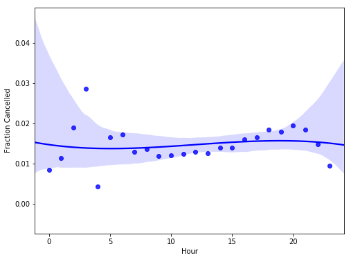

```python
fig, ax = plt.subplots(figsize=(8,6))

df = flights.groupby(['CANCELLED', flights['SCHEDULED_DEPARTURE'].apply(lambda x: x.hour)]).size()
df_pct = (df[1]/df[0]).fillna(0).rename({'SCHEDULED_DEPARTURE':'Hour', 'DAY_OF_WEEK':'Fraction Cancelled'})
df_pct = df_pct.reset_index().rename({0:'Fraction Cancelled', 'SCHEDULED_DEPARTURE':'Hour'}, axis=1)
sns.regplot('Hour', 'Fraction Cancelled', df_pct, order=3, ax=ax, color='blue')
```

There's a bit of a sinusoidal signal there, but it's weak. The bottom line is that very few flights in general are cancelled due to weather, which makes creating a predictor very difficult.

Let's move on to looking at arrival delays rather than cancellations. From both a passaeger (customer) and an operations (company) perspective, the Arrival Delay is far more important than the Departure Delay. Both the company and the customer aren't particularly impacted by a departure delay as long as they can get to their destination on time.

These next jointplots focus on the subset of the data where the weather is the worst: when the visibility is less than 5 miles and the cloud ceiling is less than 5000 ft. These are conditions where aircraft are usually flying more time-consuming instrument approaches rather than visual approaches, which intuitively would lead to more delays.

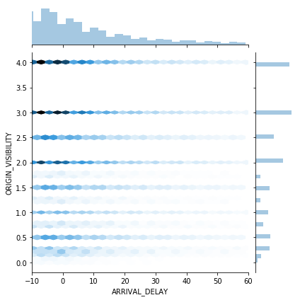

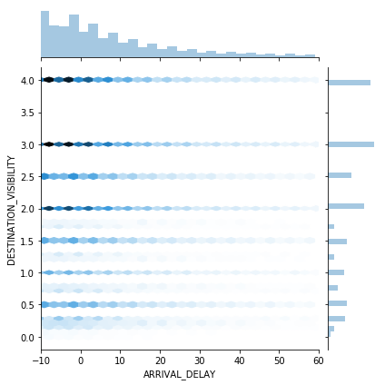

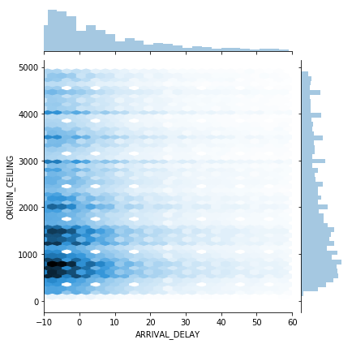

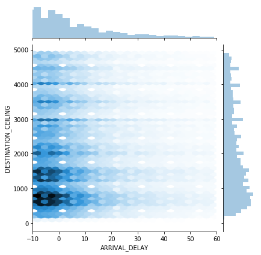

```python
sns.jointplot('ARRIVAL_DELAY', 'ORIGIN_VISIBILITY', flights[(flights['CANCELLED'] == 0) & (flights['ARRIVAL_DELAY'] < 60) & (flights['ORIGIN_VISIBILITY'] < 5)], kind='hex', xlim=(-10,60))
sns.jointplot('ARRIVAL_DELAY', 'DESTINATION_VISIBILITY', flights[(flights['CANCELLED'] == 0) & (flights['ARRIVAL_DELAY'] < 60) & (flights['DESTINATION_VISIBILITY'] < 5)], kind='hex', xlim=(-10,60))
sns.jointplot('ARRIVAL_DELAY', 'ORIGIN_CEILING', flights[(flights['CANCELLED'] == 0) & (flights['ARRIVAL_DELAY'] < 60) & (flights['ORIGIN_CEILING'] < 5000)], kind='hex', xlim=(-10,60))
sns.jointplot('ARRIVAL_DELAY', 'DESTINATION_CEILING', flights[(flights['CANCELLED'] == 0) & (flights['ARRIVAL_DELAY'] < 60) & (flights['DESTINATION_CEILING'] < 5000)], kind='hex', xlim=(-10,60))
```

Unfortunately, the plots mostly just look like a horizontal smear, indicating poor correlation. Let's see if any of the modeling algorithms can pick up on this weak signal.